# Cyclistic Bike Share Analysis in R - Capstone Project

Jason Luera

5/22/2023

## **INTRODUCTION**

The following case study serves as my capstone project for the Google Data Analytics Professional Certificate. The case study presents a scenario where you act as a junior data analyst working for the fictional company Cyclistic Bike-Share. The analyst will answer key business questions by following the data analysis process: Ask, Prepare, Process, Analyze, Share, and Act.

## **ASK**

In 2016, Cyclistic launched a successful bike-share offering. Since then, the program has grown to a fleet of 5,824 bicycles that are geotracked and locked into a network of 692 stations across Chicago. The bikes can be unlocked from one station and returned to any other station in the system anytime.

Cyclistic currently provides three pricing plans:

- Single-ride-pass
- Full-day-pass
- Annual Membership

The marketing director wants to create a campaign to convert Casual Riders (single-ride-pass or full-day-pass users) into Annual Members. The junior analyst is tasked with reviewing the prior year’s trip data to gain insights into how Casual Riders and Annual Members use Cyclistic Bike-Share differently.

Three questions will guide the future marketing program:

1. How do annual members and casual riders use Cyclistic bikes differently?
2. Why would casual riders buy Cyclistic annual memberships?
3. How can Cyclistic use digital media to influence casual riders to become members?

You will produce a report with the following deliverables:

1. A clear statement of the business task
2. A description of all data sources used
3. Documentation of any cleaning or manipulation of data
4. A summary of your analysis
5. Supporting visualizations and key findings
6. Your top three recommendations based on your analysis

### **Statement Of Business Task:**

In order to design marketing strategies aimed at converting Casual Riders into Annual Members, the provided data shall be analyzed to better understand how Annual Members and Casual Riders differ, why Casual Riders would buy a membership, and how digital media could affect their marketing tactics.

### **Description Of All Data Sources Used**

Trip data representing Cyclistic’s past year of trip records is sourced from real world data of the bike-share company Divvy. This data is provided by Lyft Bikes and Scooters, LLC which operates the City of Chicago’s Divvy bike-share service. The data comes in the form of monthly CSV files. The CSV files can be downloaded [here](https://divvy-tripdata.s3.amazonaws.com/index.html). The Data License Agreement can be found at the following [link](https://ride.divvybikes.com/data-license-agreement).

This data pulled for this analysis represents the past 12 months of trip data. There are 13 columns in each CSV file, each of which reprsents a single ride. The data has been sanitized so that there are no identifying records denoting a specific user. As such, we cannot use the data to determine how specific individuals use the service or to find trends in how they utilze multiple rides. However, we do have enough data to identify general differences between the two types of riders we are concerned with; Casual Riders and Annual Members.

## **PREPARE**

### Package Management

We will use the pacman package manager to handle the installation and loading packages.

### Install and load pacman

```r
install.packages("pacman")
library(pacman)
```

### Install and load additional packages using pacman

```r
pacman::p_load(tidyverse, janitor, lubridate, data.table, formattable, leaflet)
```

### Setting an option to prevent an unecessary error when using summarise()

```r
options(dplyr.summarise.inform = FALSE)
```

### Reading the Data

We have 12 CSV files which we will read and convert into separate dataframes, one per CSV.

### Create DataFrames from CSV Files

```r
# Read all of the CSVs into individual data frames
setwd("/home/rstudio/rstudio_projects/cyclistic_bike_share/data/")  # Set Working Directory
trips_may_22 <- read_csv("202205-divvy-tripdata.csv")
trips_jun_22 <- read_csv("202206-divvy-tripdata.csv")
trips_jul_22 <- read_csv("202207-divvy-tripdata.csv")
trips_aug_22 <- read_csv("202208-divvy-tripdata.csv")
trips_sep_22 <- read_csv("202209-divvy-tripdata.csv")
trips_oct_22 <- read_csv("202210-divvy-tripdata.csv")
trips_nov_22 <- read_csv("202211-divvy-tripdata.csv")
trips_dec_22 <- read_csv("202212-divvy-tripdata.csv")
trips_jan_23 <- read_csv("202301-divvy-tripdata.csv")
trips_feb_23 <- read_csv("202302-divvy-tripdata.csv")
trips_mar_23 <- read_csv("202303-divvy-tripdata.csv")
trips_apr_23 <- read_csv("202304-divvy-tripdata.csv")
```

### Check all DataFrames for consistent column names

```r
# Use compare_df_cols_same() to get a single comparison result
# (output of TRUE means column names are consistent between all CSV files)
compare_df_cols_same(trips_may_22, trips_jun_22, trips_jul_22, trips_aug_22, trips_sep_22, trips_oct_22, trips_nov_22, trips_dec_22, trips_jan_23, trips_feb_23, trips_mar_23, trips_apr_23 )
```

```
## [1] TRUE
```

```r
# Use compare_df_cols() to get a more details comparison of columns
compare_df_cols(trips_may_22, trips_jun_22, trips_jul_22, trips_aug_22, trips_sep_22, trips_oct_22, trips_nov_22, trips_dec_22, trips_jan_23, trips_feb_23, trips_mar_23, trips_apr_23 )
```

| column_name | trips_may_22 | trips_jun_22 | trips_jul_22 | trips_aug_22 | trips_sep_22 | trips_oct_22 | trips_nov_22 | trips_dec_22 | trips_jan_23 | trips_feb_23 | trips_mar_23 | trips_apr_23 |
| --- | --- | --- | --- | --- | --- | --- | --- | --- | --- | --- | --- | --- |
| end_lat | numeric | numeric | numeric | numeric | numeric | numeric | numeric | numeric | numeric | numeric | numeric | numeric |
| end_lng | numeric | numeric | numeric | numeric | numeric | numeric | numeric | numeric | numeric | numeric | numeric | numeric |
| end_station_id | character | character | character | character | character | character | character | character | character | character | character | character |
| end_station_name | character | character | character | character | character | character | character | character | character | character | character | character |
| ended_at | POSIXct, POSIXt | POSIXct, POSIXt | POSIXct, POSIXt | POSIXct, POSIXt | POSIXct, POSIXt | POSIXct, POSIXt | POSIXct, POSIXt | POSIXct, POSIXt | POSIXct, POSIXt | POSIXct, POSIXt | POSIXct, POSIXt | POSIXct, POSIXt |
| member_casual | character | character | character | character | character | character | character | character | character | character | character | character |
| ride_id | character | character | character | character | character | character | character | character | character | character | character | character |
| rideable_type | character | character | character | character | character | character | character | character | character | character | character | character |
| start_lat | numeric | numeric | numeric | numeric | numeric | numeric | numeric | numeric | numeric | numeric | numeric | numeric |
| start_lng | numeric | numeric | numeric | numeric | numeric | numeric | numeric | numeric | numeric | numeric | numeric | numeric |

[output cut: 3 more lines]

All CSV files have the same column names and data types. We can now merge them into a single data frame to work with

### Merge all DataFrames into one

```r
trips <- bind_rows(trips_may_22, trips_jun_22, trips_jul_22, trips_aug_22, trips_sep_22, trips_oct_22, trips_nov_22, trips_dec_22, trips_jan_23, trips_feb_23, trips_mar_23, trips_apr_23 )
```

## **PROCESS**

### Data Exploration and Data Cleaning

We now need to check over the data to verify what aspects will need to be cleaned.

### Checking for duplicate values in ride_id

If it returns TRUE then there are no duplicates.

```r
length(unique(trips$ride_id)) == nrow(trips)
```

```
## [1] TRUE
```

We have verified there are no duplicate ride_id values

### Checking for consistency in the rideable_type column

```r
trips %>% select(rideable_type) %>% unique()
```

| rideable_type |
| --- |
| classic_bike |
| docked_bike |
| electric_bike |

The rideable_type column shows three values; classic_bike, docked_bike and electronic_bike. The inclusion of a docked_bike value stands out because there are only supposed to be two types of bikes provided by the bike-share, classic and electronic.

### Checking percentage of bikes listed as docked_bike

```r
bike_usage <- trips %>%
    group_by(rideable_type) %>%
    summarise(total = n()) %>%
    mutate(overall_total = sum(total)) %>%
    group_by(rideable_type) %>%
    summarise(bike_percent_total = total/overall_total)

bike_usage
```

| rideable_type | bike_percent_total |
| --- | --- |
| classic_bike | 0.4510253 |
| docked_bike | 0.0291033 |
| electric_bike | 0.5198714 |

After further investigation it seems that this discrepancy is related to changes in the source system for Lyft (Divvy) which provided the data. It seems the term “docked_bike” is a legacy value used before changes were made to the Divvy platform in 2020. In 2020 Divvy changed the term docked_bike to classic_bike.

However, it seems that there are still some instances of “docked_bike” making it into the dataset. We will change all instances of docked_bike to classic_bike to maintain consistency.

### Rename ‘docked_bike’ value to ‘classic_bike’

```r
trips$rideable_type[trips$rideable_type == 'docked_bike'] <- 'classic_bike'
```

Lets verify the change went through correctly:

```r
bike_usage <- trips %>%
    group_by(rideable_type) %>%
    summarise(total = n()) %>%
    mutate(overall_total = sum(total)) %>%
    group_by(rideable_type) %>%
    summarise(bike_percent_total = total/overall_total)

bike_usage
```

| rideable_type | bike_percent_total |
| --- | --- |
| classic_bike | 0.4801286 |
| electric_bike | 0.5198714 |

### Adding columns so that we can easily aggregate by specific time periods

```r
trips$date <- as.Date(trips$started_at)
trips$hour <- format(trips$started_at, "%H")
trips$day <- format(as.Date(trips$started_at), "%d")
trips$month <- format(as.Date(trips$started_at), "%m")
trips$year <- format(as.Date(trips$started_at), "%Y")
trips$day_of_week <- format(as.Date(trips$started_at), "%a")
```

### Verify the columns were added correctly

```r
glimpse(trips)
```

```
## Rows: 5,859,061
## Columns: 19
## $ ride_id            <chr> "EC2DE40644C6B0F4", "1C31AD03897EE385", "1542FBEC83…
## $ rideable_type      <chr> "classic_bike", "classic_bike", "classic_bike", "cl…
## $ started_at         <dttm> 2022-05-23 23:06:58, 2022-05-11 08:53:28, 2022-05-…
## $ ended_at           <dttm> 2022-05-23 23:40:19, 2022-05-11 09:31:22, 2022-05-…
## $ start_station_name <chr> "Wabash Ave & Grand Ave", "DuSable Lake Shore Dr & …
## $ start_station_id   <chr> "TA1307000117", "13300", "TA1305000032", "TA1305000…
## $ end_station_name   <chr> "Halsted St & Roscoe St", "Field Blvd & South Water…
## $ end_station_id     <chr> "TA1309000025", "15534", "13221", "TA1305000030", "…
## $ start_lat          <dbl> 41.89147, 41.88096, 41.88224, 41.88224, 41.88224, 4…
## $ start_lng          <dbl> -87.62676, -87.61674, -87.64107, -87.64107, -87.641…
## $ end_lat            <dbl> 41.94367, 41.88635, 41.90765, 41.88458, 41.88578, 4…
## $ end_lng            <dbl> -87.64895, -87.61752, -87.67255, -87.63189, -87.651…
## $ member_casual      <chr> "member", "member", "member", "member", "member", "…
## $ date               <date> 2022-05-23, 2022-05-11, 2022-05-26, 2022-05-10, 20…
## $ hour               <chr> "23", "08", "18", "07", "17", "14", "12", "19", "17…
## $ day                <chr> "23", "11", "26", "10", "10", "04", "27", "29", "16…
## $ month              <chr> "05", "05", "05", "05", "05", "05", "05", "05", "05…
## $ year               <chr> "2022", "2022", "2022", "2022", "2022", "2022", "20…
## $ day_of_week        <chr> "Mon", "Wed", "Thu", "Tue", "Tue", "Wed", "Fri", "S…
```

### We will create a new column to track ride duration in minutes.

```r
trips$ride_duration <- round(as.numeric(difftime(trips$ended_at, trips$started_at, units='mins')), digits = 2)
```

### We will also rename a several columns to improve readability.

```r
trips <- trips %>%
  rename(ride_type = rideable_type,
         start_time = started_at,
         end_time = ended_at,
         customer_type = member_casual)
```

Verify the columns were added correctly.

```r
glimpse(trips)
```

```
## Rows: 5,859,061
## Columns: 20
## $ ride_id            <chr> "EC2DE40644C6B0F4", "1C31AD03897EE385", "1542FBEC83…
## $ ride_type          <chr> "classic_bike", "classic_bike", "classic_bike", "cl…
## $ start_time         <dttm> 2022-05-23 23:06:58, 2022-05-11 08:53:28, 2022-05-…
## $ end_time           <dttm> 2022-05-23 23:40:19, 2022-05-11 09:31:22, 2022-05-…
## $ start_station_name <chr> "Wabash Ave & Grand Ave", "DuSable Lake Shore Dr & …
## $ start_station_id   <chr> "TA1307000117", "13300", "TA1305000032", "TA1305000…
## $ end_station_name   <chr> "Halsted St & Roscoe St", "Field Blvd & South Water…
## $ end_station_id     <chr> "TA1309000025", "15534", "13221", "TA1305000030", "…
## $ start_lat          <dbl> 41.89147, 41.88096, 41.88224, 41.88224, 41.88224, 4…
## $ start_lng          <dbl> -87.62676, -87.61674, -87.64107, -87.64107, -87.641…
## $ end_lat            <dbl> 41.94367, 41.88635, 41.90765, 41.88458, 41.88578, 4…
## $ end_lng            <dbl> -87.64895, -87.61752, -87.67255, -87.63189, -87.651…
## $ customer_type      <chr> "member", "member", "member", "member", "member", "…
## $ date               <date> 2022-05-23, 2022-05-11, 2022-05-26, 2022-05-10, 20…
## $ hour               <chr> "23", "08", "18", "07", "17", "14", "12", "19", "17…
## $ day                <chr> "23", "11", "26", "10", "10", "04", "27", "29", "16…
## $ month              <chr> "05", "05", "05", "05", "05", "05", "05", "05", "05…
## $ year               <chr> "2022", "2022", "2022", "2022", "2022", "2022", "20…
## $ day_of_week        <chr> "Mon", "Wed", "Thu", "Tue", "Tue", "Wed", "Fri", "S…
## $ ride_duration      <dbl> 33.35, 37.90, 21.83, 8.70, 5.02, 7.15, 8.88, 12.17,…
```

### Summary of ride_duration column

```r
summary(trips$ride_duration)
```

```
##      Min.   1st Qu.    Median      Mean   3rd Qu.      Max.
## -10353.35      5.65      9.98     18.94     17.92  41387.25
```

From the above output you can see that the minimum ride duration has a negative duration. We will need to investigate this further. Lets see how many rows contain a ride duration with negative values

### Count rows where ride_duration is less than 0

```r
nrow(trips[trips$ride_duration < 0,])
```

```
## [1] 103
```

Slightly over one hundred rows have a negative duration times. Lets take a closer look at some of these rows with negative trip_durations.

#### View rows with ride_duration less than 0

```r
trips[trips$ride_duration < 0,]
```

| ride_id | ride_type | start_time | end_time | start_station_name | start_station_id | end_station_name | end_station_id | start_lat | start_lng | end_lat | end_lng | customer_type | date | hour | day | month | year | day_of_week | ride_duration |
| --- | --- | --- | --- | --- | --- | --- | --- | --- | --- | --- | --- | --- | --- | --- | --- | --- | --- | --- | --- |
| 0793C9208A64302A | electric_bike | 2022-05-30 11:06:29 | 2022-05-30 11:06:17 | Broadway & Waveland Ave | 13325 | NA | NA | 41.94907 | -87.64850 | 41.95000 | -87.65000 | casual | 2022-05-30 | 11 | 30 | 05 | 2022 | Mon | -0.20 |
| B897BE02B21FA75E | electric_bike | 2022-06-07 19:15:39 | 2022-06-07 17:05:37 | NA | NA | Kostner Ave & North Ave | 519 | 41.90000 | -87.74000 | 41.91000 | -87.74000 | casual | 2022-06-07 | 19 | 07 | 06 | 2022 | Tue | -130.03 |
| 072E947E156D142D | electric_bike | 2022-06-07 19:14:46 | 2022-06-07 17:07:45 | W Armitage Ave & N Sheffield Ave | 20254.0 | W Armitage Ave & N Sheffield Ave | 20254.0 | 41.92000 | -87.65000 | 41.92000 | -87.65000 | casual | 2022-06-07 | 19 | 07 | 06 | 2022 | Tue | -127.02 |
| 6A871510E302E8CD | electric_bike | 2022-06-23 19:22:57 | 2022-06-23 19:21:46 | NA | NA | Green St & Randolph St* | chargingstx3 | 41.88000 | -87.65000 | 41.88360 | -87.64863 | member | 2022-06-23 | 19 | 23 | 06 | 2022 | Thu | -1.18 |
| BF114472ABA0289C | electric_bike | 2022-06-07 19:14:47 | 2022-06-07 17:05:42 | Base - 2132 W Hubbard | Hubbard Bike-checking (LBS-WH-TEST) | W Armitage Ave & N Sheffield Ave | 20254.0 | 41.91783 | -87.65336 | 41.92000 | -87.65000 | member | 2022-06-07 | 19 | 07 | 06 | 2022 | Tue | -129.08 |
| B3BE8FE661F79405 | electric_bike | 2022-06-07 16:18:37 | 2022-06-07 16:07:28 | NA | NA | Clinton St & Washington Blvd | WL-012 | 41.88000 | -87.64000 | 41.88338 | -87.64117 | member | 2022-06-07 | 16 | 07 | 06 | 2022 | Tue | -11.15 |
| EF3CCF2B05635B96 | electric_bike | 2022-06-07 18:47:01 | 2022-06-07 17:05:41 | NA | NA | NA | NA | 41.92000 | -87.72000 | 41.93000 | -87.79000 | casual | 2022-06-07 | 18 | 07 | 06 | 2022 | Tue | -101.33 |
| BBD84670E05463A9 | electric_bike | 2022-06-07 19:11:33 | 2022-06-07 17:05:24 | NA | NA | NA | NA | 41.92000 | -87.72000 | 41.93000 | -87.72000 | casual | 2022-06-07 | 19 | 07 | 06 | 2022 | Tue | -126.15 |
| 9FE1805A2557C74A | electric_bike | 2022-06-07 19:06:49 | 2022-06-07 17:09:43 | NA | NA | NA | NA | 41.93000 | -87.76000 | 41.96000 | -87.74000 | member | 2022-06-07 | 19 | 07 | 06 | 2022 | Tue | -117.10 |
| F017ABAD58857045 | electric_bike | 2022-06-07 19:13:27 | 2022-06-07 17:07:57 | NA | NA | NA | NA | 41.93000 | -87.63000 | 41.95000 | -87.64000 | casual | 2022-06-07 | 19 | 07 | 06 | 2022 | Tue | -125.50 |

[output cut: 93 more lines]

There is some inconsistent data in regards to the started_at and ended_at times. 103 rows have started_at times that are later than the ended_at times which should not be possible. This causes negative ride durations which is not accurate and should be considered bad data.

We will drop these rows from the dataset. However, it looks like there are also a fair amount of trips with outlier values that have positive durations but are also extremely short. According to Divvy, the source of this data, any trips below 60 seconds in length are potentially false starts or users trying to re-dock a bike to ensure it was secure. As such we will remove these outliers.

### Filter out rows that have a ride duration less than 1

```r
trips <- trips[!(trips$ride_duration <= 1),]
```

### Ensure those ride durations with negative values are gone

```r
nrow(trips[trips$ride_duration < 1,])
```

```
## [1] 0
```

Now that the trips under 1 minute and those with negative durations have been removed, we can check the data for null and na values.

### Checking for nulls and NA values

```r
sum(is.null(trips))
```

```
## [1] 0
```

```r
sum(is.na(trips))
```

```
## [1] 3288211
```

### Checking how many na values are in each column.

```r
trips %>%  select(everything()) %>% summarise_all(list(~sum(is.na(.)))) %>% print(width = Inf)
```

```
## # A tibble: 1 × 20
##   ride_id ride_type start_time end_time start_station_name start_station_id
##     <int>     <int>      <int>    <int>              <int>            <int>
## 1       0         0          0        0             797038           797163
##   end_station_name end_station_id start_lat start_lng end_lat end_lng
##              <int>          <int>     <int>     <int>   <int>   <int>
## 1           840966         841104         0         0    5970    5970
##   customer_type  date  hour   day month  year day_of_week ride_duration
##           <int> <int> <int> <int> <int> <int>       <int>         <int>
## 1             0     0     0     0     0     0           0             0
```

Any NA values are not ideal but remaining places where we do have NA values are related to station names or ids and geolocation coordinates. These should not impact the analysis we are attempting to perform on this data.

### Check customer_type values for consistency

```r
trips %>% select(customer_type) %>% unique()
```

| customer_type |
| --- |
| member |
| casual |

The customer_type column values look good.

### **Summary Of Changes**

So far during the pre-processing and cleaning phase we have made the following changes:

- Merged 12 dataframes into one called trips.
- Renamed the rideable_type column values of “docked_bike” to “classic_bike” for consistency.
- Added the following columns:  
  - date  
  - hour  
  - day  
  - month  
  - year  
  - day_of_week  
  - ride_duration
- Renamed the following columns:  
  - Changed rideable_type to ride_type  
  - Changed started_at to start_time  
  - Changed ended_at to end_time  
  - Changed member_casual to customer_type
- Filtered out rows where the ride_duration is less than 1, including many negative duration values.

## **ANALYZE**

We now begin the process of gaining insights from the data.

### Comparing trip duration between members and casuals

```r
aggregate(trips$ride_duration ~ trips$customer_type, FUN = mean)
```

| trips$customer_type | trips$ride_duration |
| --- | --- |
| casual | 29.13629 |
| member | 12.81587 |

```r
aggregate(trips$ride_duration ~ trips$customer_type, FUN = median)
```

| trips$customer_type | trips$ride_duration |
| --- | --- |
| casual | 12.83 |
| member | 8.90 |

```r
aggregate(trips$ride_duration ~ trips$customer_type, FUN = min)
```

| trips$customer_type | trips$ride_duration |
| --- | --- |
| casual | 1.02 |
| member | 1.02 |

```r
aggregate(trips$ride_duration ~ trips$customer_type, FUN = max)
```

| trips$customer_type | trips$ride_duration |
| --- | --- |
| casual | 41387.25 |
| member | 1559.67 |

### Summary of trips dataframe

```r
summary(trips)
```

```
##    ride_id           ride_type           start_time
##  Length:5717237     Length:5717237     Min.   :2022-05-01 00:00:06.00
##  Class :character   Class :character   1st Qu.:2022-07-02 23:37:43.00
##  Mode  :character   Mode  :character   Median :2022-08-28 00:23:04.00
##                                        Mean   :2022-09-19 02:01:51.93
##                                        3rd Qu.:2022-11-07 10:56:06.00
##                                        Max.   :2023-04-30 23:59:05.00
##
##     end_time                      start_station_name start_station_id
##  Min.   :2022-05-01 00:05:17.00   Length:5717237     Length:5717237
##  1st Qu.:2022-07-03 00:04:35.00   Class :character   Class :character
##  Median :2022-08-28 00:47:21.00   Mode  :character   Mode  :character
##  Mean   :2022-09-19 02:21:15.76
##  3rd Qu.:2022-11-07 11:11:52.00
##  Max.   :2023-05-03 10:37:12.00
##
##  end_station_name   end_station_id       start_lat       start_lng
##  Length:5717237     Length:5717237     Min.   :41.64   Min.   :-87.84
##  Class :character   Class :character   1st Qu.:41.88   1st Qu.:-87.66
##  Mode  :character   Mode  :character   Median :41.90   Median :-87.64
##                                        Mean   :41.90   Mean   :-87.65
##                                        3rd Qu.:41.93   3rd Qu.:-87.63
##                                        Max.   :42.07   Max.   :-87.52
##
##     end_lat         end_lng       customer_type           date
##  Min.   : 0.00   Min.   :-88.14   Length:5717237     Min.   :2022-05-01
##  1st Qu.:41.88   1st Qu.:-87.66   Class :character   1st Qu.:2022-07-02
##  Median :41.90   Median :-87.64   Mode  :character   Median :2022-08-28
##  Mean   :41.90   Mean   :-87.65                      Mean   :2022-09-18
##  3rd Qu.:41.93   3rd Qu.:-87.63                      3rd Qu.:2022-11-07
##  Max.   :42.37   Max.   :  0.00                      Max.   :2023-04-30
##  NA's   :5970    NA's   :5970
##      hour               day               month               year
##  Length:5717237     Length:5717237     Length:5717237     Length:5717237
##  Class :character   Class :character   Class :character   Class :character
##  Mode  :character   Mode  :character   Mode  :character   Mode  :character
##
##
##
##
##  day_of_week        ride_duration
##  Length:5717237     Min.   :    1.02
##  Class :character   1st Qu.:    5.92
##  Mode  :character   Median :   10.25
##                     Mean   :   19.40
##                     3rd Qu.:   18.23
##                     Max.   :41387.25
##
```

### Calculate total rides by customer type

```r
customer_rides <- table(trips$customer_type)
customer_rides
```

```
##
##  casual  member
## 2305553 3411684
```

### Calculate average ride duration by customer type (in minutes)

```r
avg_ride_time <- trips %>%
    group_by(customer_type) %>%
    summarise(avg_time = mean(ride_duration), .groups = "drop")

avg_ride_time$avg_time <- round(avg_ride_time$avg_time, digits = 0)

avg_ride_time
```

| customer_type | avg_time |
| --- | --- |
| casual | 29 |
| member | 13 |

### Calculate percentage of rides by customer type

```r
customer_percent <- trips %>%
    group_by(customer_type) %>%
    summarise(total = n()) %>%
    mutate(overall_total = sum(total)) %>%
    group_by(customer_type) %>%
    summarise(customer_percent_total = total/overall_total)

customer_percent
```

| customer_type | customer_percent_total |
| --- | --- |
| casual | 0.4032635 |
| member | 0.5967365 |

### Calculate percentage of rides by bike type

```r
bike_usage_perc <- trips %>%
    group_by(ride_type) %>%
    summarise(total = n()) %>%
    mutate(overall_total = sum(total)) %>%
    group_by(ride_type) %>%
    summarise(bike_percent_total = total/overall_total)

bike_usage
```

| rideable_type | bike_percent_total |
| --- | --- |
| classic_bike | 0.4801286 |
| electric_bike | 0.5198714 |

### Create DF of bike preference by customer type

```r
ride_pref_by_cust  <- trips %>%
  group_by(customer_type, ride_type) %>%
  summarise(number_of_rides = n()) %>%
  arrange(ride_type)

ride_pref_by_cust
```

| customer_type | ride_type | number_of_rides |
| --- | --- | --- |
| casual | classic_bike | 1047017 |
| member | classic_bike | 1724524 |
| casual | electric_bike | 1258536 |
| member | electric_bike | 1687160 |

### Calculate number of rides per day by customer type

```r
trips %>%
  group_by(customer_type, day_of_week) %>%
  summarise(number_of_rides = n(), avg_length = mean(ride_duration), median_length = median(ride_duration),
            max_length = max(ride_duration), min_length = min(ride_duration), .groups = 'drop')
```

| customer_type | day_of_week | number_of_rides | avg_length | median_length | max_length | min_length |
| --- | --- | --- | --- | --- | --- | --- |
| casual | Fri | 342209 | 28.14168 | 12.48 | 32402.97 | 1.02 |
| casual | Mon | 269723 | 28.99252 | 12.50 | 32035.45 | 1.02 |
| casual | Sat | 457414 | 32.97450 | 14.82 | 41387.25 | 1.02 |
| casual | Sun | 380127 | 34.19208 | 14.87 | 36257.80 | 1.02 |
| casual | Thu | 311314 | 25.25769 | 11.62 | 31023.50 | 1.02 |
| casual | Tue | 266471 | 25.91345 | 11.37 | 31085.85 | 1.02 |
| casual | Wed | 278295 | 24.70903 | 11.25 | 35820.63 | 1.02 |
| member | Fri | 484702 | 12.68003 | 8.78 | 1499.93 | 1.02 |
| member | Mon | 472456 | 12.27462 | 8.47 | 1499.95 | 1.02 |
| member | Sat | 442544 | 14.29487 | 9.85 | 1559.67 | 1.02 |

[output cut: 4 more lines]

### Calculate number of rides per hour by customer type

```r
hourly <- trips %>%
    group_by(customer_type, hour) %>%
    summarise(number_of_rides = n()) %>%
      arrange(hour)

hourly
```

| customer_type | hour | number_of_rides |
| --- | --- | --- |
| casual | 00 | 45917 |
| member | 00 | 36589 |
| casual | 01 | 29666 |
| member | 01 | 22345 |
| casual | 02 | 18350 |
| member | 02 | 13126 |
| casual | 03 | 10762 |
| member | 03 | 8017 |
| casual | 04 | 7483 |
| member | 04 | 8877 |

[output cut: 38 more lines]

#### Calculate number of rides per month by customer type

```r
monthly <- trips %>%
    group_by(customer_type, month) %>%
    summarise(number_of_rides = n())

monthly
```

| customer_type | month | number_of_rides |
| --- | --- | --- |
| casual | 01 | 38826 |
| casual | 02 | 41809 |
| casual | 03 | 60266 |
| casual | 04 | 142488 |
| casual | 05 | 275082 |
| casual | 06 | 361865 |
| casual | 07 | 397552 |
| casual | 08 | 351089 |
| casual | 09 | 290322 |
| casual | 10 | 204157 |

[output cut: 14 more lines]

### Which stations are more popular per rider type?

It turns out that there are quite a bit of missing values when it comes to starting stations. This can be due to the fact that not all bikes are returned to starting stations by the rider. For example, electronic bikes can locked to public racks without having to dock it at a station. It seems clear that classic bikes are not always returned to the proper stations as well.

As such, when calculating the top starting stations we will filter out rows where the start_station_name is NA.

#### Top 10 starting stations for Casual Riders

```r
casual_top_stations <- trips %>%
  group_by(start_station_name, customer_type) %>%
  filter(!is.na(start_station_name)) %>%
  filter(customer_type == "casual") %>%
  summarise(number_of_rides = n()) %>%
  arrange(desc(number_of_rides))

head(casual_top_stations, 10)
```

| start_station_name | customer_type | number_of_rides |
| --- | --- | --- |
| Streeter Dr & Grand Ave | casual | 56378 |
| DuSable Lake Shore Dr & Monroe St | casual | 31501 |
| Michigan Ave & Oak St | casual | 24957 |
| Millennium Park | casual | 24812 |
| DuSable Lake Shore Dr & North Blvd | casual | 23218 |
| Shedd Aquarium | casual | 20053 |
| Theater on the Lake | casual | 18227 |
| Wells St & Concord Ln | casual | 16240 |
| Dusable Harbor | casual | 14035 |
| Indiana Ave & Roosevelt Rd | casual | 13665 |

“Streeter Dr & Grand Ave” is the most popular starting station for Casual Riders by a wide margin.

#### Top 10 starting stations for Annual Members

```r
member_top_stations <- trips %>%
  group_by(start_station_name, customer_type) %>%
  filter(!is.na(start_station_name)) %>%
  filter(customer_type == "member") %>%
  summarise(number_of_rides = n()) %>%
  arrange(desc(number_of_rides))

head(member_top_stations, 10)
```

| start_station_name | customer_type | number_of_rides |
| --- | --- | --- |
| Kingsbury St & Kinzie St | member | 24875 |
| Clark St & Elm St | member | 22784 |
| University Ave & 57th St | member | 21676 |
| Wells St & Concord Ln | member | 21646 |
| Clinton St & Washington Blvd | member | 21091 |
| Ellis Ave & 60th St | member | 20895 |
| Loomis St & Lexington St | member | 20278 |
| Wells St & Elm St | member | 19505 |
| Clinton St & Madison St | member | 18951 |
| Broadway & Barry Ave | member | 18275 |

“Kingsbury St & Kinzie St” is the most popular starting station for Annual Members, but it is not that far ahead of the next several stations that follow it.

### **Summary Of Analysis**

- **Rider Distribution**: Annual Members make up the majority of rides with 59.67% of the ride share compared to 40.33% from Casual Riders.
- **Ride Duration**: Casual Riders tend to take the longest rides on average, with an average ride duration of 29 minutes compared to 13 minutes for Annual Members.
- **Peak Weekly Traffic**: Traffic for Casual Riders tends to peak on the weekends whereas Annual Members tend to ride more during the week days.
- **Peak Daily Traffic**: On average, traffic for both Casual Riders and Annual Members peaks around 5:00pm every day, with the 4:00pm to 6:00pm range being significantly higher than the rest of the day.
- **Peak Seasonal Traffic**: The bike-share tends to be more popular in the summer months for both types of customers. However, the ride increase during the summer months is significantly higher with the Casual Riders compared to the Annual Members.
- **Bike Preference**: Casual Riders seem to prefer Electric Bikes whereas Annual Members seem to have a very slight preference for Classic Bikes.
- **Ride Locality**: Casual Riders tend to stick around the Lake Shore Drive region of Downtown Chicago, rarely going more than a few blocks from it. Annual Members tend to spread their rides out more across the entire downtown Chicago area.

## **SHARE**

The following includes various visualizations to support these findings.

### Distribution of Rides by Member Type

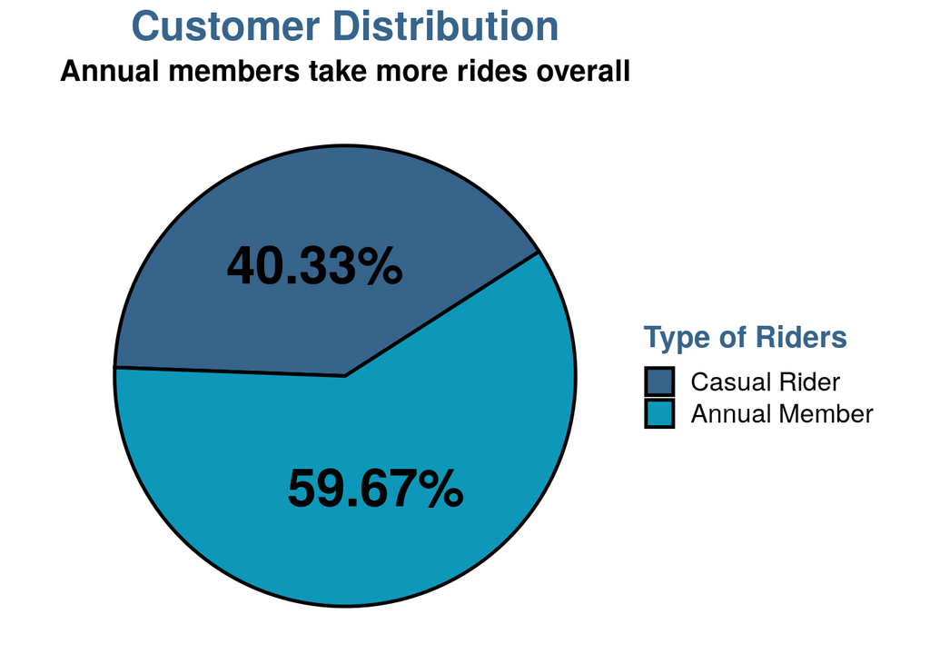

```r
trips_summary <- trips %>%
  count(customer_type) %>%
  mutate(ride_percentage = formattable((n / sum(n)) * 100), digits = 2)


pie_labels <- paste0( trips_summary$ride_percentage,"%")

ggplot(trips_summary, aes(x = "", y = ride_percentage, fill = customer_type)) +
    geom_col(color = "black", linewidth = 0.9) +
    coord_polar("y", start = 1) +
    geom_text(aes(label = pie_labels), position = position_stack(vjust = 0.5), size = 10, fontface = "bold", color = "black") +
scale_fill_manual(values = c("steelblue4", "#0d98ba"), name = "Type of Riders", breaks = c("casual", "member"), labels = c("Casual Rider", "Annual Member")) +
labs(title = "Customer Distribution", subtitle = "Annual members take more rides overall") +
theme_void() +
theme(plot.title = element_text(hjust = 0.5, size = 22, face = "bold", color = "steelblue4"),
    plot.subtitle = element_text(hjust = 0.5, size = 16, face = "bold", color = "black"),
    plot.caption = element_text(size = 8, color = "black"),
    legend.title = element_text(size = 16, face = "bold", color = "steelblue4"),
    legend.text = element_text(size = 14, color = "black"))
```

From the data we can see that Annual Members take more rides overall compared to Casual Riders

### Average Ride Duration by Member Type

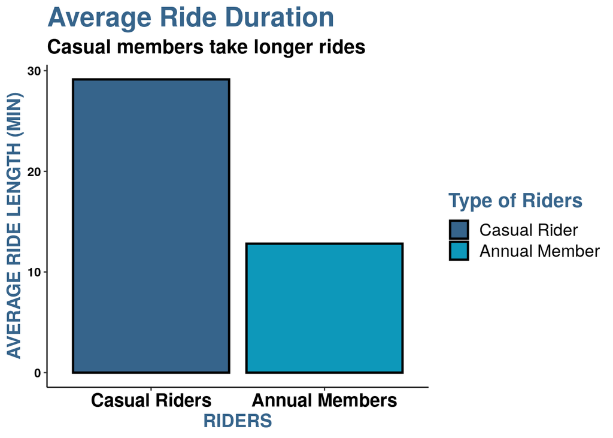

```r
average_ride_duration <- trips %>%
  group_by(customer_type) %>%
  summarise(average_ride_duration = mean(ride_duration))

ggplot(average_ride_duration, aes(x = customer_type, y = average_ride_duration, fill = customer_type)) +
  geom_bar(stat = "identity", color = "black", linewidth = 0.9) +
  scale_x_discrete(labels=c('Casual Riders', 'Annual Members')) +
  labs(title = "Average Ride Duration", subtitle = "Casual members take longer rides", x = "RIDERS", y = "AVERAGE RIDE LENGTH (MIN)") +
  scale_fill_manual(values = c("steelblue4", "#0d98ba"), name = "Type of Riders", breaks = c("casual", "member"), labels = c("Casual Rider", "Annual Member")) +
 theme_classic() +
  theme(plot.title = element_text(size = 22, face = "bold", color = "steelblue4"),
  plot.subtitle = element_text(size = 16, face = "bold", color = "black"),
  plot.caption = element_text(size = 8, color = "black"),
  legend.title = element_text(size = 16, face = "bold", color = "steelblue4"),
  legend.text = element_text(size = 14, color = "black"),
  axis.title.x = element_text(size = 15, color = "steelblue4", face = "bold"),
  axis.title.y = element_text(size = 15, color = "steelblue4", face = "bold"),
  axis.text.x = element_text(size = 15, color = "black", face = "bold"),
  axis.text.y = element_text(size = 10, color = "black", face = "bold"))
```

Despite the fact that Annual Members take the most rides overall, we can see that Casual riders take the longest rides on average.

### Daily Usage

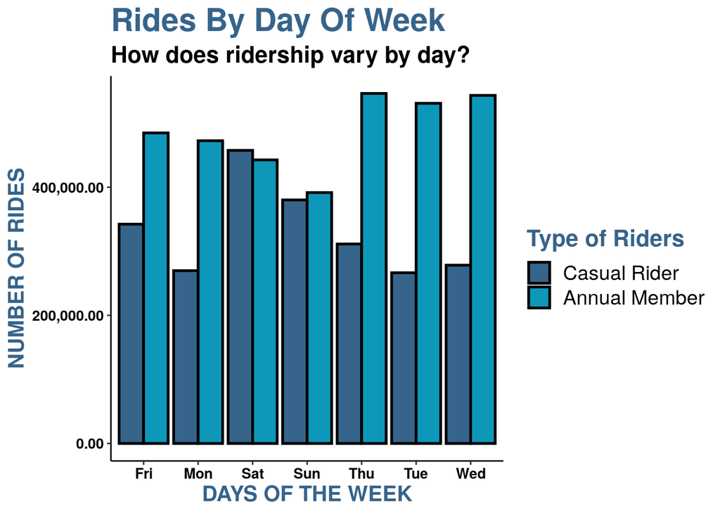

```r
trips %>%
  group_by(customer_type, day_of_week) %>%
  summarise(number_of_rides = n(), average_duration = mean(ride_duration), .groups = 'drop') %>%
  arrange(customer_type, day_of_week) %>%
  ggplot(aes(x = day_of_week, y = number_of_rides, fill = customer_type)) +
  geom_col(position = "dodge", color = "black", linewidth = 0.9) +
  labs(x = "DAYS OF THE WEEK", y = "NUMBER OF RIDES", title = "Rides By Day Of Week", subtitle = "How does ridership vary by day?") +
  scale_y_continuous(labels = comma) +
  scale_fill_manual(values = c("steelblue4", "#0d98ba"), name = "Type of Riders", breaks = c("casual", "member"), labels = c("Casual Rider", "Annual Member")) +
 theme_classic() +
  theme(plot.title = element_text(size = 22, face = "bold", color = "steelblue4"),
  plot.subtitle = element_text(size = 16, face = "bold", color = "black"),
  plot.caption = element_text(size = 8, color = "black"),
  legend.title = element_text(size = 16, face = "bold", color = "steelblue4"),
  legend.text = element_text(size = 14, color = "black"),
  axis.title.x = element_text(size = 15, color = "steelblue4", face = "bold"),
  axis.title.y = element_text(size = 15, color = "steelblue4", face = "bold"),
  axis.text.x = element_text(size = 10, color = "black", face = "bold"),
  axis.text.y = element_text(size = 10, color = "black", face = "bold"))
```

We can see that Casual Riders traffic peaks on the weekend while Annual Members are busiest on weekdays. Its highly likely that annual members are primarily using the bike-share to get to and from work.

### Number of rides by hour

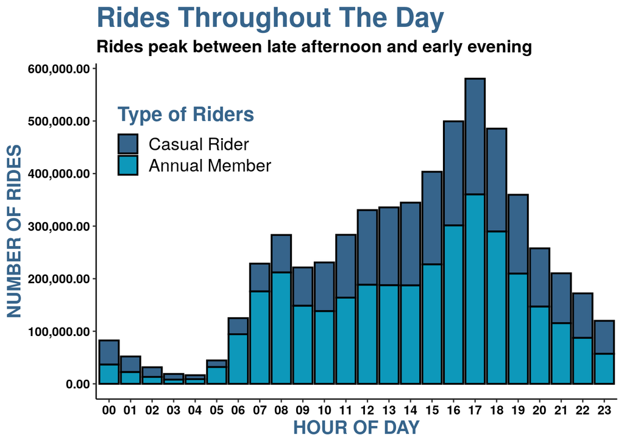

```r
ggplot(hourly, aes(hour, number_of_rides, fill = customer_type, group=customer_type)) +
geom_bar(stat = "identity", color = "black", linewidth = 0.7 ) +
scale_y_continuous(labels = comma, breaks = seq(0, 6000000, by = 100000) ) +
scale_fill_manual(values = c("steelblue4", "#0d98ba"), name = "Type of Riders", breaks = c("casual", "member"), labels = c("Casual Rider", "Annual Member")) +
labs(title = "Rides Throughout The Day", subtitle = "Rides peak between late afternoon and early evening",
    x = "HOUR OF DAY", y = "NUMBER OF RIDES") +
theme_classic() +
theme(
      plot.title = element_text(size = 22, color = "steelblue4", face = "bold"),
      plot.subtitle = element_text(size = 14, color = "black", face = "bold"),
      plot.caption = element_text(size = 8, color = "black"),
      legend.title = element_text(size = 16, face = "bold", color = "steelblue4"),
      legend.text = element_text(size = 14, color = "black"),
      axis.title.x = element_text(size = 15, color = "steelblue4", face = "bold"),
      axis.title.y = element_text(size = 15, color = "steelblue4", face = "bold"),
      axis.text.x = element_text(size = 10, color = "black", face = "bold"),
      axis.text.y = element_text(size = 10, color = "black", face = "bold"),
      legend.position = c(.35, .90),
      legend.justification = c("right", "top"),
      legend.box.just = "right",
      legend.margin = margin(6, 6, 6, 6))
```

We can see that the peak time for rides is between 4:00pm and 6:00pm. This is consistent for both Casual Riders and Annual Members.

### Rides by Month

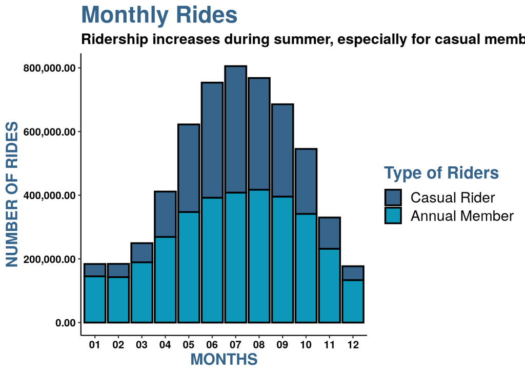

```r
ggplot(monthly, aes(month, number_of_rides, fill = customer_type, group = customer_type)) +
  geom_bar(stat = "identity", color = "black", linewidth=0.8) +
  scale_y_continuous(labels = comma,) +
  scale_fill_manual(values = c("steelblue4", "#0d98ba"), name = "Type of Riders", breaks = c("casual", "member"), labels = c("Casual Rider", "Annual Member")) +
  labs(title = "Monthly Rides", subtitle = "Ridership increases during summer, especially for casual members",
    x = "MONTHS", y = "NUMBER OF RIDES") +
  theme_classic() +
  theme(plot.title = element_text(size = 22, color = "steelblue4", face = "bold"),
    plot.subtitle = element_text(size = 14, color = "black", face = "bold"),
    plot.caption = element_text(size = 8, color = "black"),
    legend.title = element_text(size = 16, face = "bold", color = "steelblue4"),
    legend.text = element_text(size = 14, color = "black"),
    axis.title.x = element_text(size = 15, color = "steelblue4", face = "bold"),
    axis.title.y = element_text(size = 15, color = "steelblue4", face = "bold"),
    axis.text.x = element_text(size = 10, color = "black", face = "bold"),
    axis.text.y = element_text(size = 10, color = "black", face = "bold"))
```

From the data we can see that the summer is busiest for both Casual Riders and Annual Members. That makes sense considering Chicago gets pretty cold during late fall and winter time. We also see that rides for Casual Riders are significantly higher in the summer, which we believe is likely due to the increase of tourist activity during summer months.

### Preferred Bike Type Per Rider

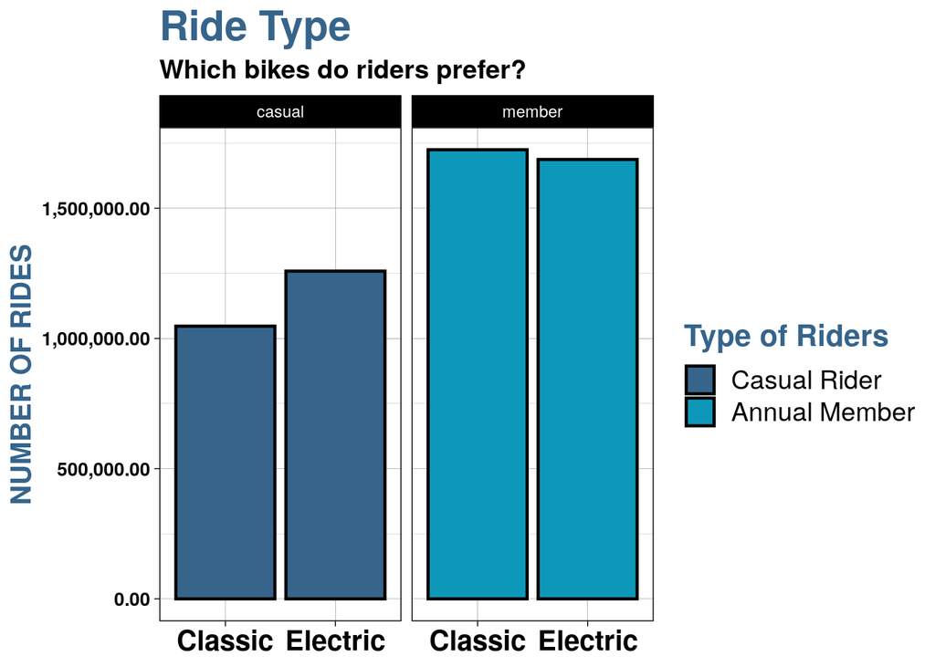

```r
ggplot(ride_pref_by_cust, aes(x=ride_type, y=number_of_rides, fill=customer_type)) +
  geom_bar(stat = "identity", color = "black", linewidth=0.8) +
  scale_y_continuous(labels = comma, breaks = seq(0, 2000000, by = 500000) ) +
  scale_x_discrete(labels=c('Classic', 'Electric', 'Classic', 'Electric')) +
  facet_wrap(~customer_type) +
  scale_fill_manual(values = c("steelblue4", "#0d98ba"), name = "Type of Riders", breaks = c("casual", "member"), labels = c("Casual Rider", "Annual Member")) +
  labs(title = "Ride Type", subtitle = "Which bikes do riders prefer?",
    x = "RIDE TYPE", y = "NUMBER OF RIDES") +
  theme_linedraw() +
  theme(plot.title = element_text(size = 22, color = "steelblue4", face = "bold"),
    plot.subtitle = element_text(size = 14, color = "black", face = "bold"),
    plot.caption = element_text(size = 8, color = "black"),
    legend.title = element_text(size = 16, face = "bold", color = "steelblue4"),
    legend.text = element_text(size = 14, color = "black"),
    axis.title.x = element_blank(),
    axis.title.y = element_text(size = 15, color = "steelblue4", face = "bold"),
    axis.text.x = element_text(size = 15, color = "black", face = "bold", angle =0),
    axis.text.y = element_text(size = 10, color = "black", face = "bold"))
```

Casual Riders appears to prefer electric bikes while Annual Members have a slight preference for classic bikes.

### And finally, lets visualize a map with starting locations by customer type

```r
stations <- trips %>%
group_by(start_station_name, customer_type) %>%
summarise(number_of_rides = n()) %>%
arrange(desc(number_of_rides))

station_geo <- trips %>%
select(start_station_name, start_lat, start_lng) %>%
distinct(start_station_name, .keep_all = TRUE)

geo_data <- stations %>%
left_join(station_geo, by = "start_station_name")

ride_map <- leaflet() %>%
    addTiles()

ride_map <- ride_map %>%
  addCircleMarkers(
    data = subset(geo_data[1:100,], customer_type == "casual"),
    lat = ~start_lat,
    lng = ~start_lng,
    label = ~paste(start_station_name, "Rides:", number_of_rides),
    color = "navy",
    radius = 5,
    group = "Casual",
    opacity = 0.5
  ) %>%
  addCircleMarkers(
    data = subset(geo_data[1:100,], customer_type == "member"),
    lat = ~start_lat,
    lng = ~start_lng,
    label = ~paste(start_station_name, "Rides:", number_of_rides),
    color = "#0d98ba",
    radius = 5,
    group = "Member",
    opacity = 0.7
  )

ride_map <- ride_map %>%
  addLayersControl(
    overlayGroups = c("Casual", "Member"),
    options = layersControlOptions(collapsed = FALSE)
  )

ride_map
```

[interactive chart not shown]

## **ACT**

Before we offer our suggestions, lets have a quick recap of some of the key deliverables referenced earlier:

### **Statement Of Business Task:**

In order to design marketing strategies aimed at converting Casual Riders into Annual Members, the provided data shall be analyzed to better understand how Annual Members and Casual Riders differ, why Casual Riders would buy a membership, and how digital media could affect their marketing tactics.

### **Description Of All Data Sources Used**

Trip data representing Cyclistic’s past year of trip records is sourced from real world data of the bike-share company Divvy. This data is provided by Lyft Bikes and Scooters, LLC which operates the City of Chicago’s Divvy bike-share service. The data comes in the form of monthly CSV files. The CSV files can be downloaded [here](https://divvy-tripdata.s3.amazonaws.com/index.html). The Data License Agreement can be found at the following [link](https://ride.divvybikes.com/data-license-agreement).

This data pulled for this analysis represents the past 12 months of trip data. There are 13 columns in each CSV file, each of which reprsents a single ride. The data has been sanitized so that there are no identifying records denoting a specific user. As such, we cannot use the data to determine how specific individuals use the service or to find trends in how they utilze multiple rides. However, we do have enough data to identify general differences between the two types of riders we are concerned with; Casual Riders and Annual Members.

### **Summary Of Changes**

So far during the pre-processing and cleaning phase we have made the following changes:

- Merged 12 dataframes into one called trips.
- Renamed the rideable_type column values of “docked_bike” to “classic_bike” for consistency.
- Added the following columns:  
  - date  
  - hour  
  - day  
  - month  
  - year  
  - day_of_week  
  - ride_duration
- Renamed the following columns:  
  - Changed rideable_type to ride_type  
  - Changed started_at to start_time  
  - Changed ended_at to end_time  
  - Changed member_casual to customer_type
- Filtered out rows where the ride_duration is less than 1, including many negative duration values.

### **Summary Of Analysis**

- **Rider Distribution**: Annual Members make up the majority of rides with 59.67% of the ride share compared to 40.33% from Casual Riders.
- **Ride Duration**: Casual Riders tend to take the longest rides on average, with an average ride duration of 29 minutes compared to 13 minutes for Annual Members.
- **Peak Weekly Traffic**: Traffic for Casual Riders tends to peak on the weekends whereas Annual Members tend to ride more during the week days.
- **Peak Daily Traffic**: On average, traffic for both Casual Riders and Annual Members peaks around 5:00pm every day, with the 4:00pm to 6:00pm range being significantly higher than the rest of the day.
- **Peak Seasonal Traffic**: The bike-share tends to be more popular in the summer months for both types of customers. However, the ride increase during the summer months is significantly higher with the Casual Riders compared to the Annual Members.
- **Bike Preference**: Casual Riders seem to prefer Electric Bikes whereas Annual Members seem to have a very slight preference for Classic Bikes.
- **Ride Locality**: Casual Riders tend to stick around the Lake Shore Drive region of Downtown Chicago, rarely going more than a few blocks from it. Annual Members tend to spread their rides out more across the entire downtown Chicago area.

### **Based on this analysis, my recommendations are as follows:**

1. **Consider adding an alternative membership or additional plans which are catered to Casual Riders**. Considering that Casual Riders tend to ride mainly during the summer months, take much longer rides compared to Annual Members, and stick to a smaller area of downtown Chicago near Shoreline Drive, it seems highly probable that a large segment of this group includes visitors to Chicago. A yearly membership may not be very appealing to this type of rider. However, you could offer additional packages which would suit them better. For example, adding a summertime membership with an allowance for longer rides may be a good way to entice Casual Riders to pay for a membership. Likewise, consider offering a weekend only membership or a week long pass option, which may go a long way towards enticing different segments of Casual Riders into paying more ahead of time. For those Casual Riders who do live in the downtown Chicago area, another option which may lead to more Annual Membership signups is increasing the allotted ride time for Annual Members, especially for users of Classic Bikes which are more affordable but would also take longer to reach their destination.
2. **Initiate a survey campaign for market research**. Obtain better data from actual Casual Riders to see why they use the bike-share service and why they have not signed up for an Annual Membership. Given the current data, all we can do is speculate on why Casual Riders are using the service the way that they do. I suggest we run a targeted survey campaign focused primarily on Casual Riders. We would offer discounts or an extended ride time to a randomized selection of Casual Riders in exchange for them answering a short survey. This would provide us which much better information regarding the target customer and we can hear from them directly on why they use the service and why they don’t pay for the Annual Membership. That information could then be used to improve business decisions in the future.
3. **Initiate a campaign utilizing local “influencers” and social media to spread the word on the benefits of an Annual Membership**. Target some of the more popular “influencers” in town to help advertise the bike-share service to locals and visitors alike. Have those selected demonstrate how convenient the Cyclistic bike-share product is, and how easy it is to quickly get to various popular spots in downtown Chicago while using it. Likewise, run a social media campaign utilizing Annual Members and offer a discount or various perks if they make a social media post mentioning why they love using Cyclistic bike-share.

### **REFERENCES**

- [RDocumentation](https://www.rdocumentation.org/)
- [R Charts](https://r-charts.com/)
- [The R Graph Gallery](https://r-graph-gallery.com/index.html)
- [rstudio Community](https://community.rstudio.com/)
- [Kaggle Community](https://www.kaggle.com/)
- [Stack Overflow](https://stackoverflow.com/)